# Quiz 01 - Statisitical Learning

In this assessment we would using the `College` data set which can be found in the file `College.csv` on the book website. It contains a number of variables for 777 different universities and colleges in the US.

The variables are

- `Private` : Public/Private indicator
- `Apps` : Number of applications received
- `Accept` : Number of applicants accepted
- `Enroll` : Number of new students enrolled
- `Top10perc` : New students from top 10 % of high school class
- `Top25perc` : New students from top 25 % of high school class
- `F.Undergrad` : Number of full-time undergraduates
- `P.Undergrad` : Number of part-time undergraduates
- `Outstate` : Out-of-state tuition
- `Room.Board` : Room and board costs
- `Books` : Estimated book costs
- `Personal` : Estimated personal spending
- `PhD` : Percent of faculty with Ph.D.’s
- `Terminal` : Percent of faculty with terminal degree
- `S.F.Ratio` : Student/faculty ratio
- `perc.alumni` : Percent of alumni who donate
- `Expend` : Instructional expenditure per student
- `Grad.Rate` : Graduation rate

(a) Use the `read.csv()` function to read the data into `R`. Call the loaded data college. Make sure that you have the directory set to the correct location for the data

```r
# your code here
college <- read.csv('College.csv')
```

```r
# hidden test case
```

(b) Use the `dim()` function to produce the dimensions of the data set.

```r
#dims = ?
# your code here
dims = dim(college)
dims
```

1. 777

2. 19

```r
#hidden tests
```

(c) Use the `pairs()` function to produce a scatterplot matrix of the first ten columns or variables of the data. Recall that you can reference the first ten columns of a `matrix A` using `A[,1:10]`

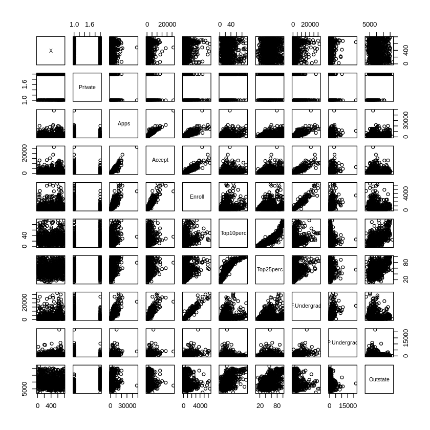

```r
#pairs = ?
# your code here
pairs = pairs(college[,1:10])
```

```r
#hidden test cases
```

(d) Use the `plot()` function to produce side-by-side boxplots of Outstate versus Private

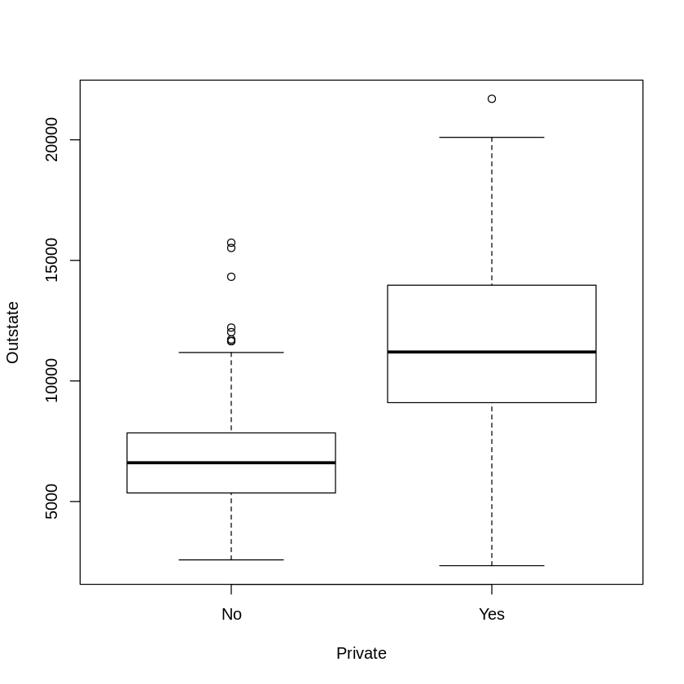

```r
# your code here
#boxplot(college$Private, college$Outstate)
boxplot(Outstate ~ Private, data=college)
```

(e) Create a new qualitative variable, called `Elite`, by binning the `Top10perc` variable. Divide universities into two groups based on whether or not the proportion of students coming from the top `10%` of their high school classes exceeds `50 %`.

`Elite` should contain `Yes` or `No` based on the above condition

```r
#Elite = ?
# your code here

Elite = ifelse(college$Top10perc > 50, 'Yes', 'No')
#Elite
```

```r
#hidden test cases
```

```r
Elite <- as.factor(Elite)
college <- data.frame(college, Elite)
```

(d) use the `plot()` function to produce side-by-side boxplots of Outstate versus Elite.

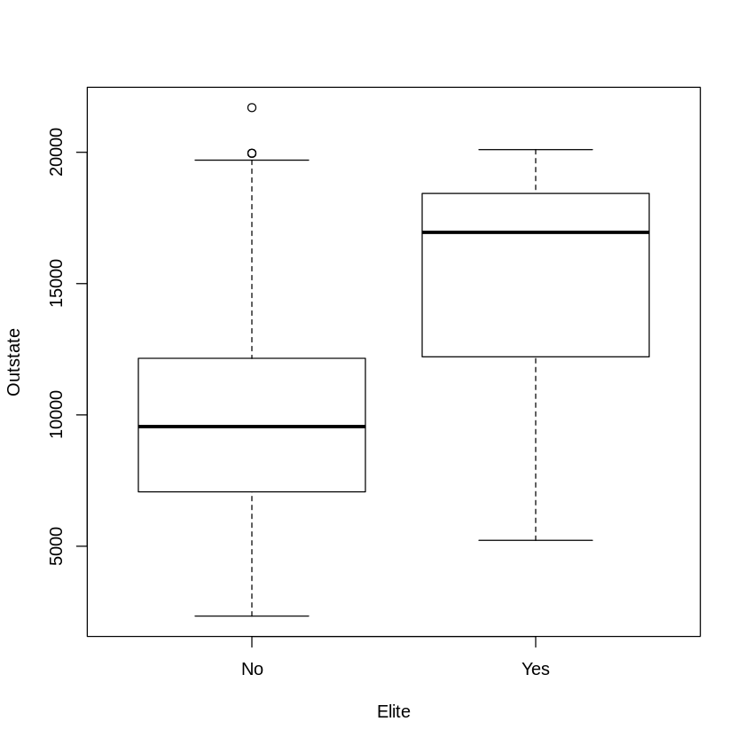

```r
# your code here
#boxplot(cbind(college$Elite, college$Outstate), beside=T)
boxplot(Outstate ~ Elite, data=college)
```